# Proyecto

Stefan Quintana

2023-03-23

```
##      Edad           Causa.de.muerte        Total            Hombres
##  Length:5316        Length:5316        Min.   :    1.0   Min.   :    0
##  Class :character   Class :character   1st Qu.:   33.0   1st Qu.:   19
##  Mode  :character   Mode  :character   Median :   89.0   Median :   53
##                                        Mean   :  644.6   Mean   :  363
##                                        3rd Qu.:  225.0   3rd Qu.:  136
##                                        Max.   :85600.0   Max.   :47002
##     Mujeres           año_info
##  Min.   :    0.0   Min.   :2009
##  1st Qu.:    9.0   1st Qu.:2011
##  Median :   31.0   Median :2014
##  Mean   :  281.6   Mean   :2014
##  3rd Qu.:   94.0   3rd Qu.:2017
##  Max.   :38598.0   Max.   :2019
```

```
## 'data.frame':    5316 obs. of  6 variables:
##  $ Edad           : chr  "Todas las edades" "Todas las edades" "Todas las edades" "Todas las edades" ...
##  $ Causa.de.muerte: chr  "Todas las causas" "Neumonía, organismo no especificado" "Agresión con disparo de otras armas de fuego, y las no especificadas" "Exposición a factores no especificados" ...
##  $ Total          : int  71707 7013 5000 3693 3410 2997 2502 2031 1738 1720 ...
##  $ Hombres        : int  41354 3770 4512 3077 1843 1275 1340 931 1162 846 ...
##  $ Mujeres        : int  30353 3243 488 616 1567 1722 1162 1100 576 874 ...
##  $ año_info       : int  2009 2009 2009 2009 2009 2009 2009 2009 2009 2009 ...
```

Se tienen 6 variables Edad <- Variable categórica Causa.De.Muerte <- Variable cualitativa Total <- Variable cuantitativa Hombres <- Variable cuantitativa Mujeres <- Variable cuantitativa año_info <- Variable categórica

Ahora, se procede a observar si las variables cuantitativas respetan una distribución normal.

### Total

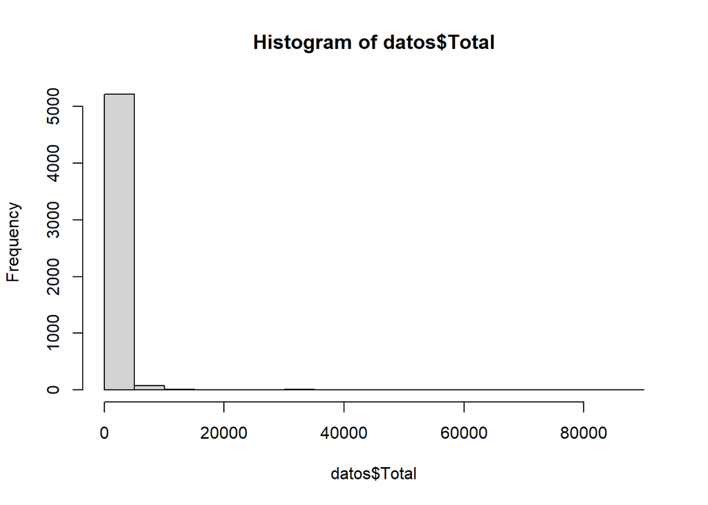

```r
library(nortest)
hist(datos$Total)
```

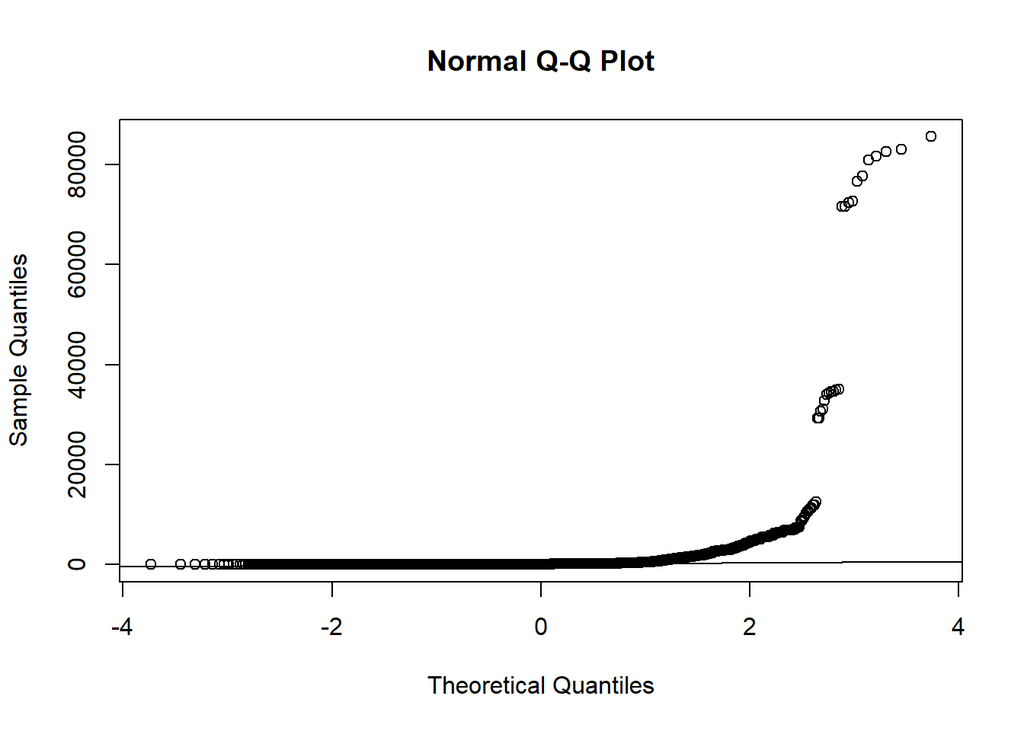

```r
qqnorm(datos$Total)
qqline(datos$Total)
```

```r
lillie.test(datos$Total)
```

```
##
##  Lilliefors (Kolmogorov-Smirnov) normality test
##
## data:  datos$Total
## D = 0.43555, p-value < 2.2e-16
```

Basándose en la gráfica, donde se puede notar que los puntos se alejan de la recta teórica, podemos argumentar que los datos no respetan una distribución normal, lo cuál se confirma en el test Lillie, donde se rechaza la hipótesis nula, por lo tanto, se concluye que los datos no provienen de una distribución normal.

### Hombres

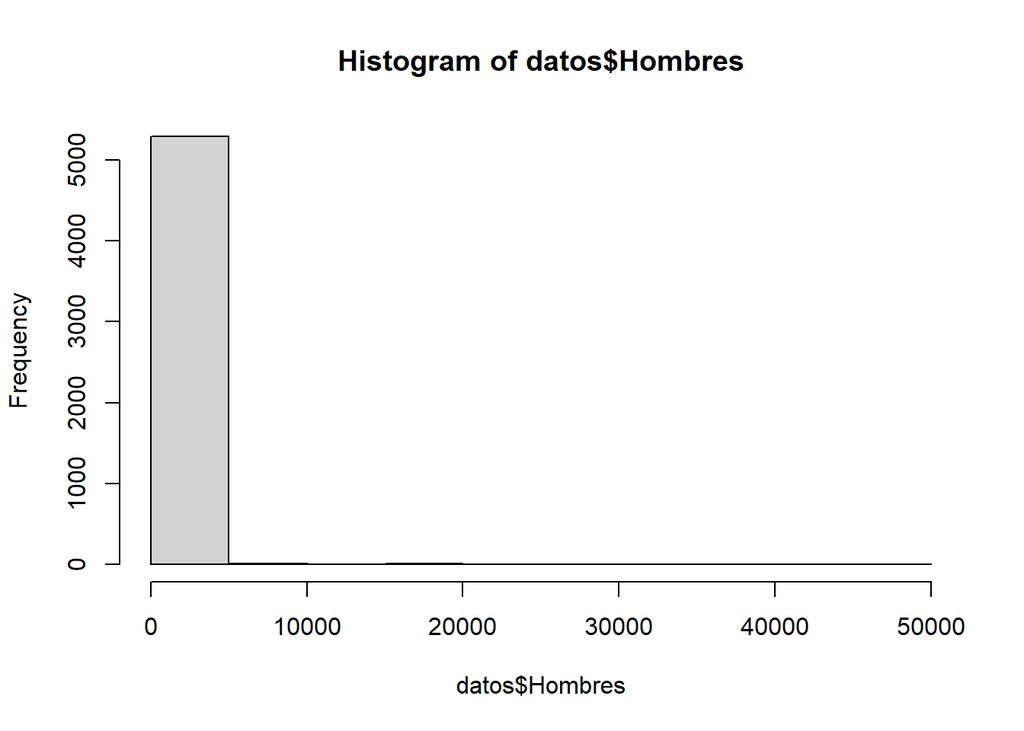

```r
hist(datos$Hombres)
```

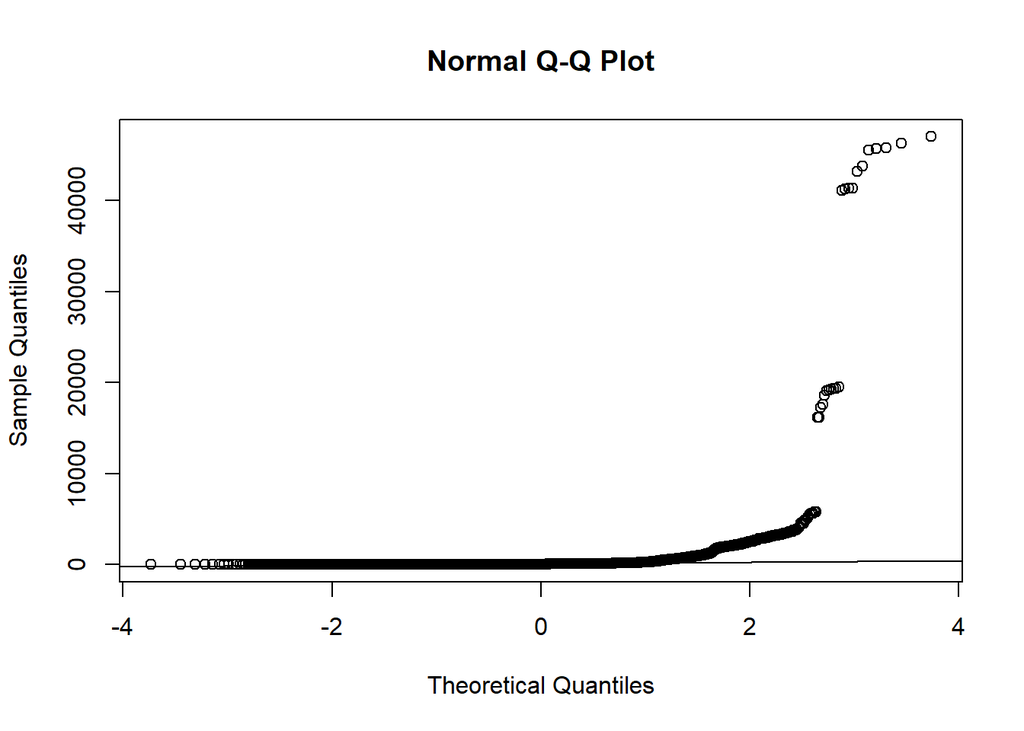

```r
qqnorm(datos$Hombres)
qqline(datos$Hombres)
```

```r
lillie.test(datos$Hombres)
```

```
##
##  Lilliefors (Kolmogorov-Smirnov) normality test
##
## data:  datos$Hombres
## D = 0.43518, p-value < 2.2e-16
```

Al igual que con los datos Totales, las muertes de los hombres no respetan una distribución normal.

### Mujeres

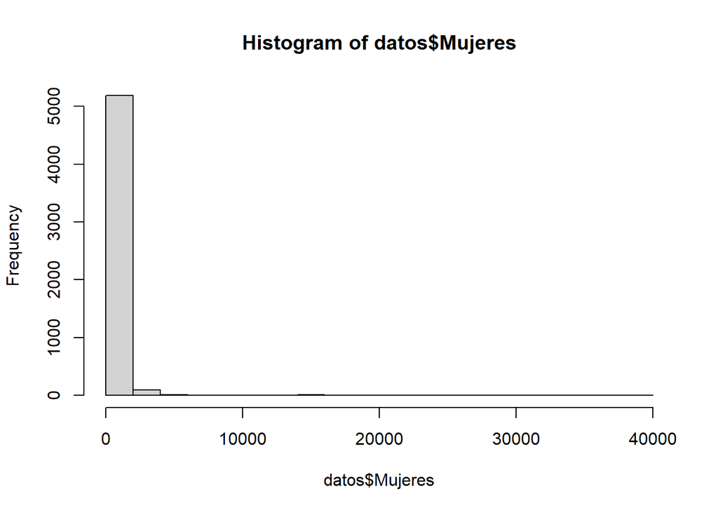

```r
hist(datos$Mujeres)
```

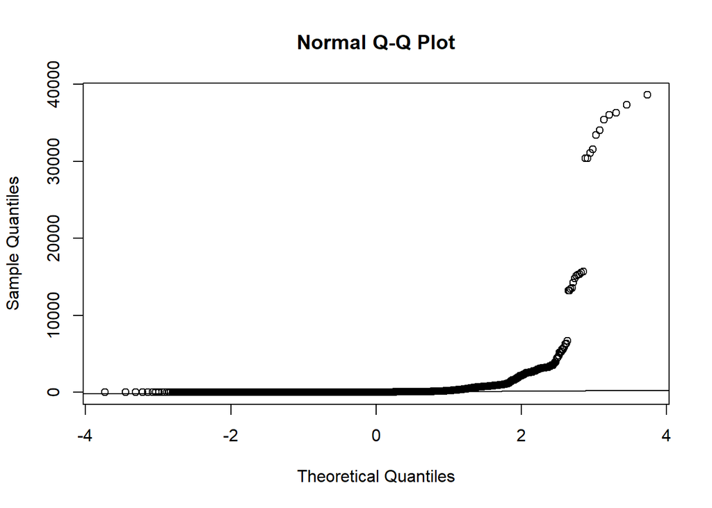

```r
qqnorm(datos$Mujeres)
qqline(datos$Mujeres)
```

```r
lillie.test(datos$Mujeres)
```

```
##
##  Lilliefors (Kolmogorov-Smirnov) normality test
##
## data:  datos$Mujeres
## D = 0.43604, p-value < 2.2e-16
```

Ahora, se crean bases de datos agrupadas por causas de muerte y por año

```r
datos_causa <- datos %>% group_by(Causa.de.muerte) %>% summarize(HombresTot = sum(Hombres), MujeresTot = sum(Mujeres), Tot = sum(Total))

datos_anual <- datos %>% group_by(año_info) %>% summarize(HombresTot = sum(Hombres), MujeresTot = sum(Mujeres), Tot = sum(Total))
```

Se realiza el análisis de distribución a las mismas variables con las nuevas bases de datos:

## Causa

### Hombres

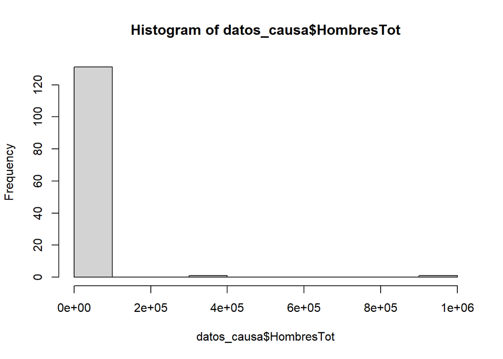

```r
hist(datos_causa$HombresTot)
```

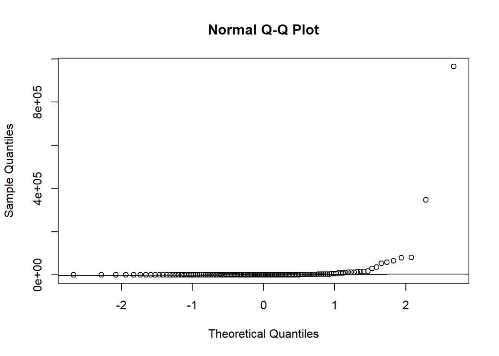

```r
qqnorm(datos_causa$HombresTot)
qqline(datos_causa$HombresTot)
```

```r
lillie.test(datos_causa$HombresTot)
```

```
##
##  Lilliefors (Kolmogorov-Smirnov) normality test
##
## data:  datos_causa$HombresTot
## D = 0.43544, p-value < 2.2e-16
```

Se revela con el test y con las gráficas que las muertes de los hombres no respetan una distribución normal si se agrupan por causa.

### Mujeres

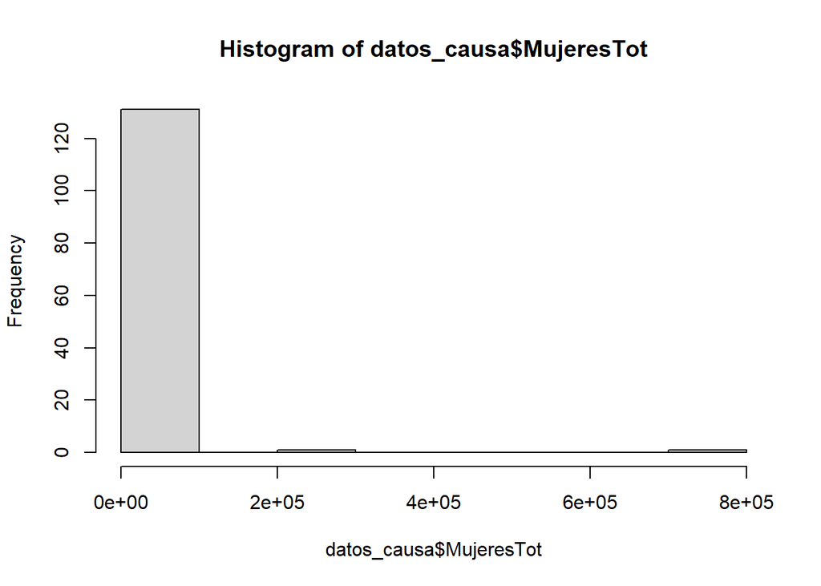

```r
hist(datos_causa$MujeresTot)
```

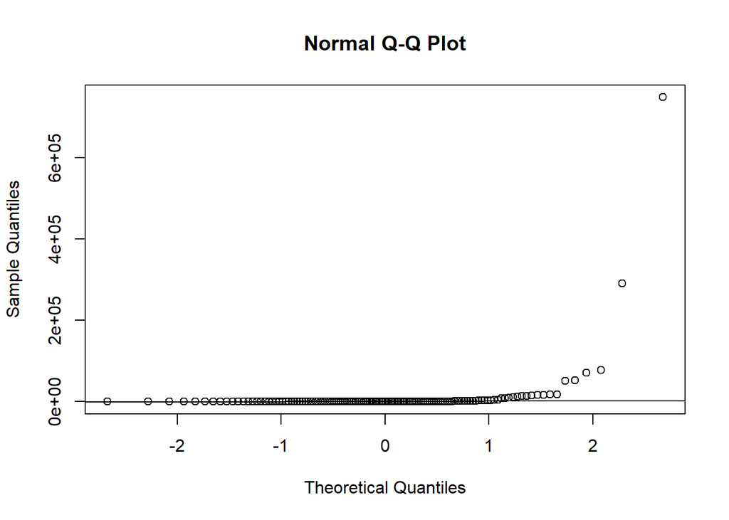

```r
qqnorm(datos_causa$MujeresTot)
qqline(datos_causa$MujeresTot)
```

```r
lillie.test(datos_causa$MujeresTot)
```

```
##
##  Lilliefors (Kolmogorov-Smirnov) normality test
##
## data:  datos_causa$MujeresTot
## D = 0.4361, p-value < 2.2e-16
```

Se revela con el test y con las gráficas que los decesis de las mujeres no respetan una distribución normal si se agrupan por causa.

### Total

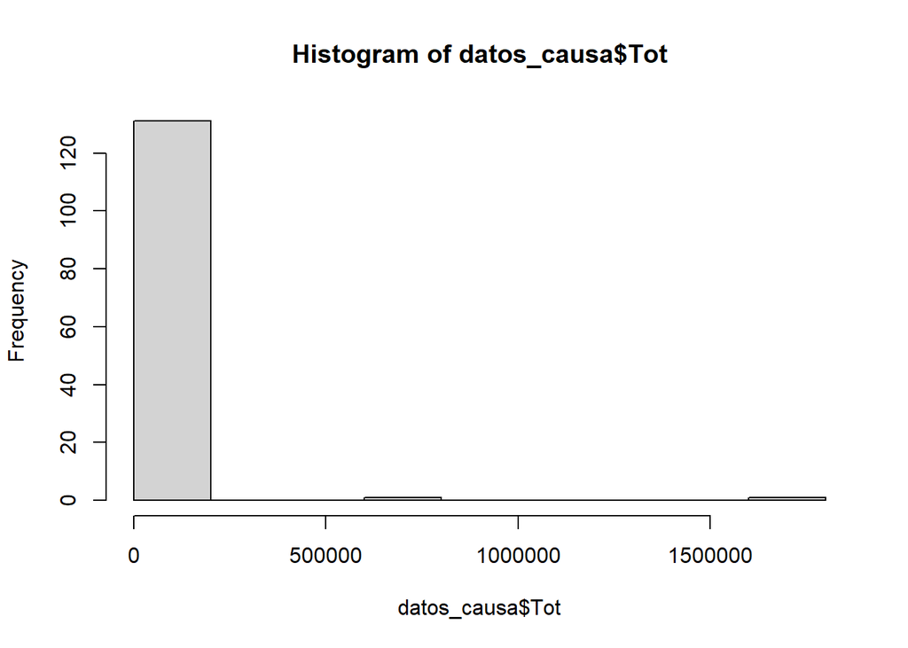

```r
hist(datos_causa$Tot)
```

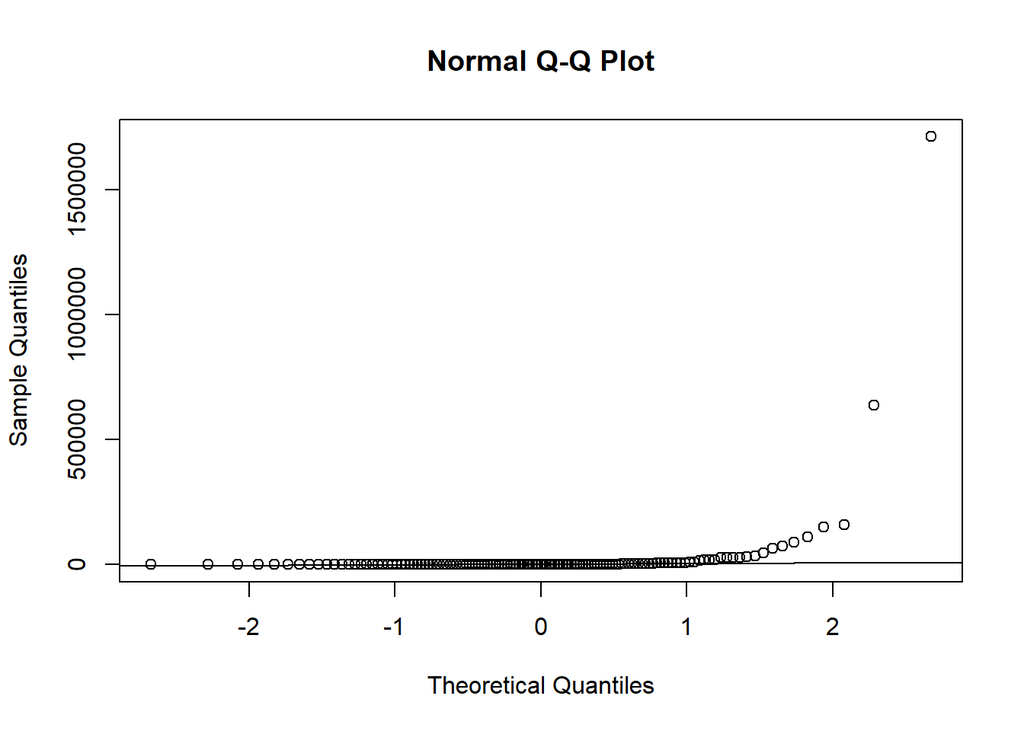

```r
qqnorm(datos_causa$Tot)
qqline(datos_causa$Tot)
```

```r
lillie.test(datos_causa$Tot)
```

```
##
##  Lilliefors (Kolmogorov-Smirnov) normality test
##
## data:  datos_causa$Tot
## D = 0.43569, p-value < 2.2e-16
```

Al igual que con los datos pasados el total de decesos no respeta una distribución normal si son agrupadas por causa.

## Año

### Hombres

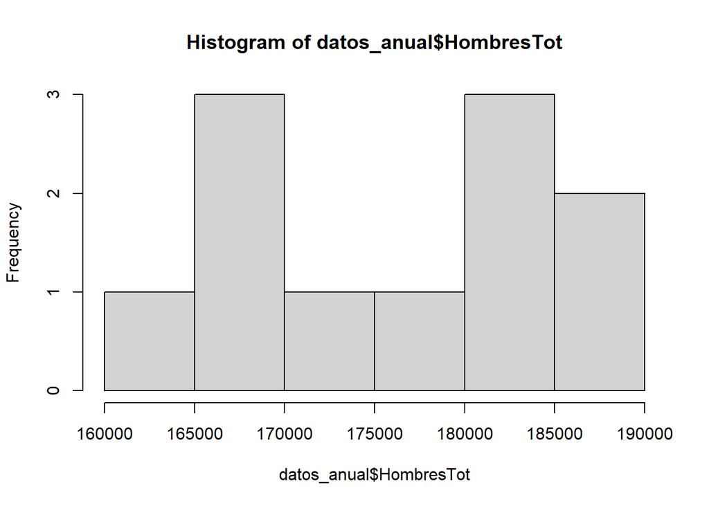

```r
hist(datos_anual$HombresTot)
```

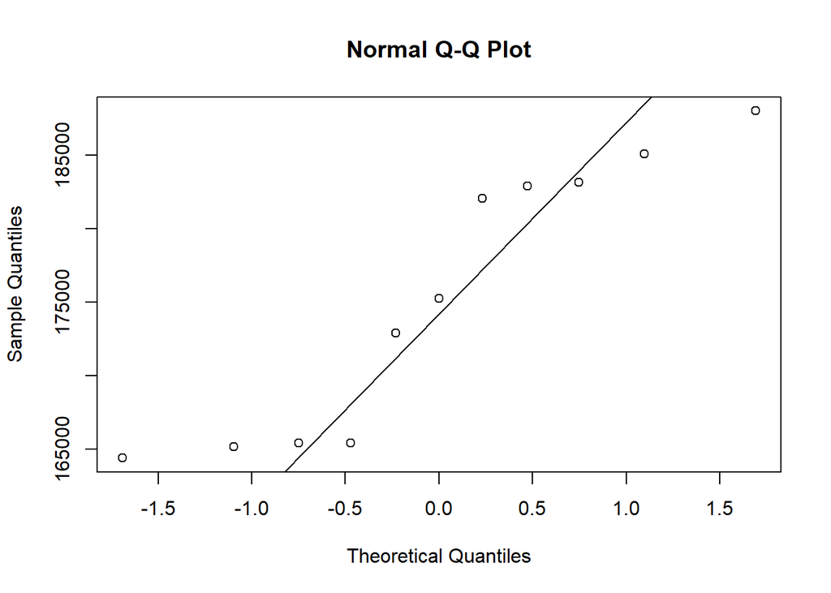

```r
qqnorm(datos_anual$HombresTot)
qqline(datos_anual$HombresTot)
```

```r
lillie.test(datos_anual$HombresTot)
```

```
##
##  Lilliefors (Kolmogorov-Smirnov) normality test
##
## data:  datos_anual$HombresTot
## D = 0.2257, p-value = 0.1213
```

Ya que el valor-p en el test de Lillie es mayor a 0.05 no se puede concluir que los decesos de los hombres no respetan una distribución normal si se agrupan por año.

### Mujeres

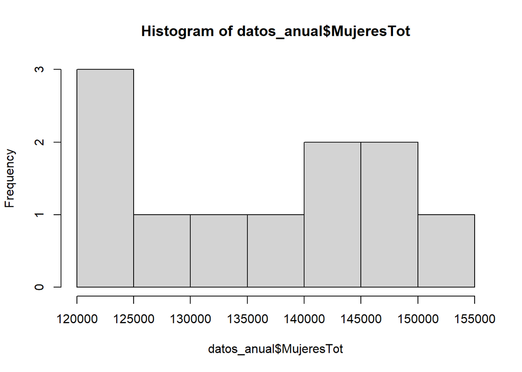

```r
hist(datos_anual$MujeresTot)
```

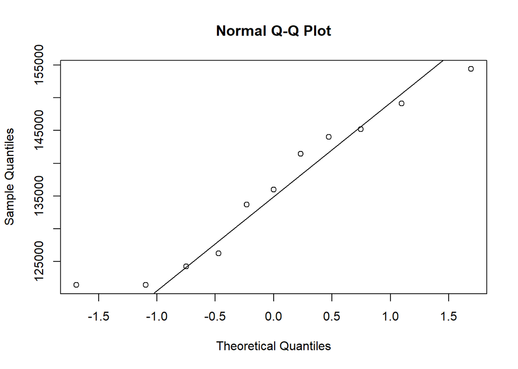

```r
qqnorm(datos_anual$MujeresTot)
qqline(datos_anual$MujeresTot)
```

```r
lillie.test(datos_anual$MujeresTot)
```

```
##
##  Lilliefors (Kolmogorov-Smirnov) normality test
##
## data:  datos_anual$MujeresTot
## D = 0.16551, p-value = 0.5454
```

Al igual que con los decesos de los hombres, no se puede concluir que las muertes de las mujeres no respetan una distribución normal.

### Total

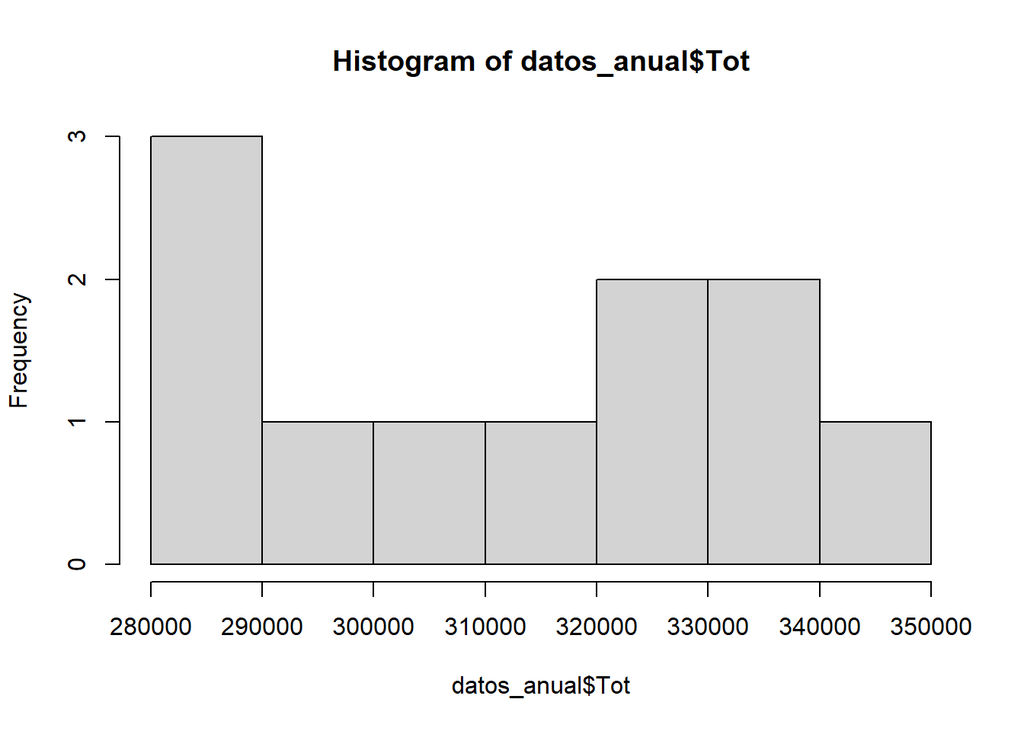

```r
hist(datos_anual$Tot)
```

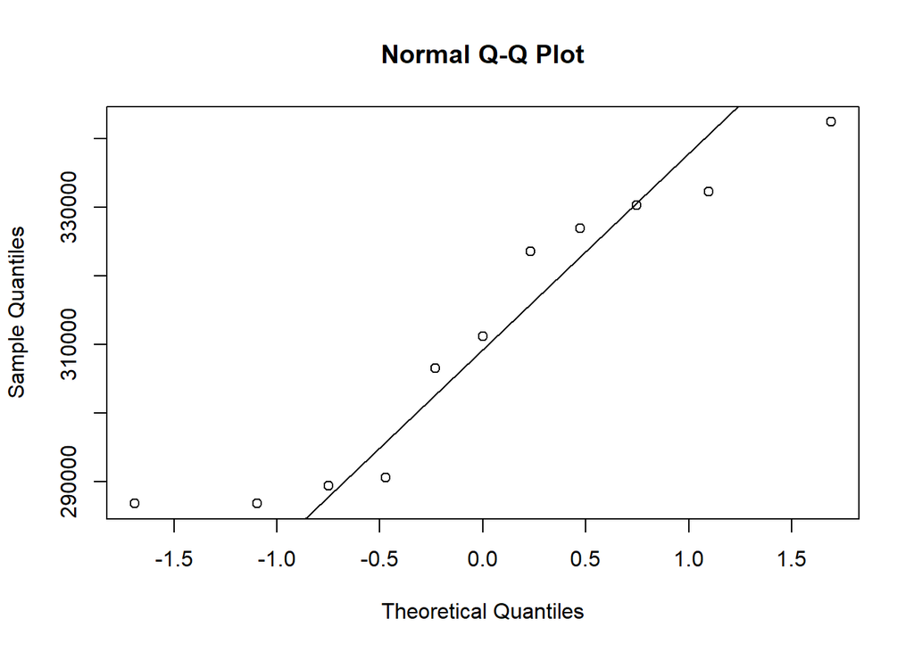

```r
qqnorm(datos_anual$Tot)
qqline(datos_anual$Tot)
```

```r
lillie.test(datos_anual$Tot)
```

```
##
##  Lilliefors (Kolmogorov-Smirnov) normality test
##
## data:  datos_anual$Tot
## D = 0.20732, p-value = 0.2065
```

Con un valor-p mayor a 0.05 no se puede concluir que el Total de decesos no se ajusta a una distribución normal si se agrupan por año.